# Differentialy expression by LN group

Sara Gosline

7/12/2021

## Dive into lymph node status to investigate possible data separation

To build a model we want to break down patient samples into various classes based on their lymph node status.

Let’s first start by seeing how many patients have positive lymph nodes:

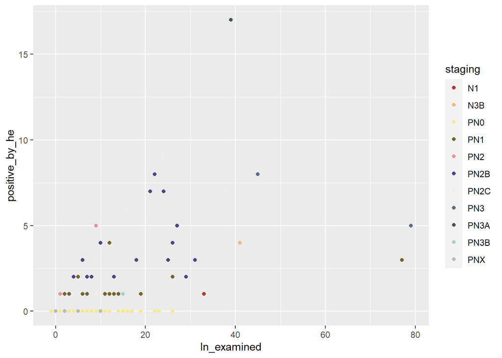

```r
       ggplot(clin.dat,aes(x=ln_examined,y=positive_by_he,col=staging))+geom_point()+
  scale_color_manual(values=pal)
```

It seems that there is a large number that have 0 positive lymph nodes, a group that has just 1, and a group that has 2 or more.

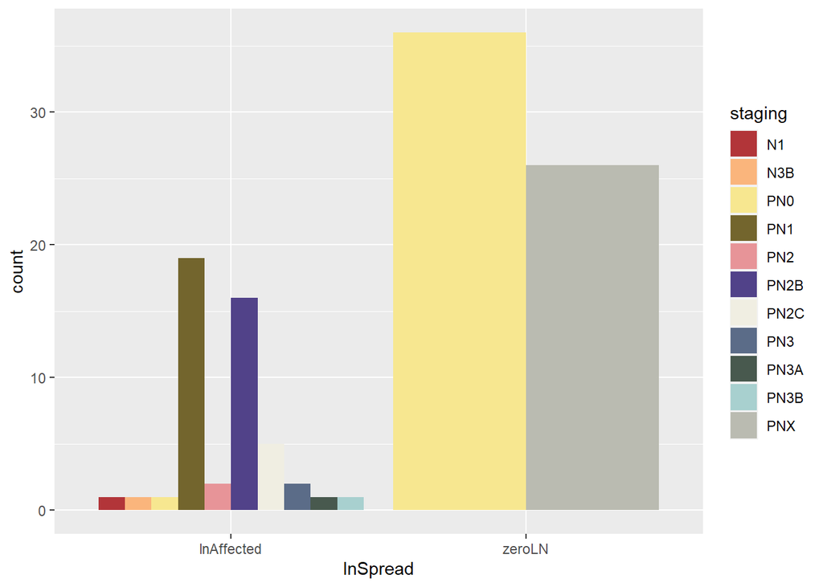

```r
ggplot(red.dat,aes(x=lnSpread,fill=staging))+geom_bar(position='dodge')+scale_fill_manual(values=pal)
```

## Differential tumor expression

Now we can compute proteins that are differentially expressed between LN classes.

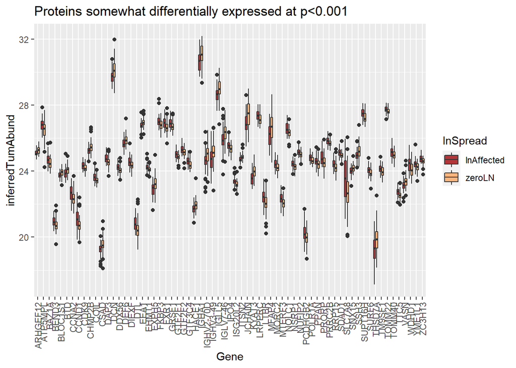

```r
library(limma)

#create data matrix of samples and collect patients
protMat<-tumProts%>%
        pivot_wider(values_from='inferredTumAbund',names_from='patient')%>%
        tibble::column_to_rownames('Gene')

zpats=red.dat%>%subset(lnSpread=='zeroLN')%>%
        select(patient)%>%
        subset(patient%in%colnames(protMat))

opats=red.dat%>%subset(lnSpread=='lnAffected')%>%
        select(patient)%>%
        subset(patient%in%colnames(protMat))


doLim<-function(dat,sampleIDs.group1,sampleIDs.group2){
  fac <- factor(rep(c(2,1), c(length(sampleIDs.group2), length(sampleIDs.group1))))
  design <- model.matrix(~fac)
  fit <- lmFit(dat[,c(sampleIDs.group2, sampleIDs.group1)], design)
  fit <- eBayes(fit)
  res <- topTable(fit, coef=2, number=Inf, sort.by="none")
  res <- data.frame(featureID=rownames(res), res, stringsAsFactors = F)
  return(res)
}

oneVsZero=doLim(protMat,opats$patient,zpats$patient)
oneVsZero%>%subset(P.Value<0.001)%>%
  rename(Gene='featureID')%>%left_join(tumProts)%>%
  left_join(red.dat)%>%
  ggplot(aes(x=Gene,y=inferredTumAbund))+geom_boxplot(aes(fill=lnSpread))+scale_x_discrete(guide = guide_axis(angle = 90))+ggtitle('Proteins somewhat differentially expressed at p<0.001')+scale_fill_manual(values=pal)
```

```r
##now
```

### Biological pathway enrichment

Let’s compute the pathways (NCI Pathways) enriched upon proteins that are different between zero and 1/2 LN affected

```r
library(leapr)

data("ncipid")
data('krbpaths')
z.en <- leapR(geneset=ncipid,enrichment_method='enrichment_in_order',datamatrix=oneVsZero,primary_columns='logFC')%>%
        subset(BH_pvalue<0.01)

DT::datatable(select(z.en,-ingroupnames))
```

|  | ingroup_n | ingroup_mean | outgroup_n | outgroup_mean | score | oddsratio | pvalue | BH_pvalue | SignedBH_pvalue | background_n | background_mean | zscore |
| --- | --- | --- | --- | --- | --- | --- | --- | --- | --- | --- | --- | --- |
| aurora_b_pathway | 26 | -0.102346984018581 | 9916 | 0.00347422259604334 |  | 0.538197784466441 | 5.3757002859145e-06 | 0.000173814309244569 | -0.000173814309244569 |  |  | -1.12914000232381 |
| bcr_5pathway | 53 | 0.0652661629084004 | 9916 | 0.00347422259604334 |  | -0.387450813246364 | 1.35069936602061e-06 | 5.24071354015998e-05 | 5.24071354015998e-05 |  |  | 0.807959584654507 |
| cd8tcrpathway | 41 | 0.087669412783948 | 9916 | 0.00347422259604334 |  | -0.486594712659511 | 8.40566801385556e-07 | 4.07674898671995e-05 | 4.07674898671995e-05 |  |  | 1.10468443885523 |
| cxcr3pathway | 31 | 0.0747967172270376 | 9916 | 0.00347422259604334 |  | -0.404188733750602 | 0.000136013931242296 | 0.00239879115100049 | 0.00239879115100049 |  |  | 0.722345576147533 |
| cxcr4_pathway | 80 | 0.0557759414696391 | 9916 | 0.00347422259604334 |  | -0.30408682936668 | 5.81900766549737e-05 | 0.00125431943011832 | 0.00125431943011832 |  |  | 0.507931364222011 |
| e2f_pathway | 52 | -0.0564560673175354 | 9916 | 0.00347422259604334 |  | 0.312001202255812 | 0.000863274990481222 | 0.00930418600851984 | -0.00930418600851984 |  |  | -0.544738215014073 |
| epopathway | 25 | 0.0780714268649055 | 9916 | 0.00347422259604334 |  | -0.457281161758774 | 0.000574976781672176 | 0.00656149974378836 | 0.00656149974378836 |  |  | 1.03935576465312 |
| erbb1_downstream_pathway | 83 | 0.0392386950711651 | 9916 | 0.00347422259604334 |  | -0.243828885530018 | 8.17664058909706e-05 | 0.00158626827428483 | 0.00158626827428483 |  |  | 0.458310199247634 |
| fcer1pathway | 47 | 0.0622043192431117 | 9916 | 0.00347422259604334 |  | -0.387265798666243 | 1.59917635134121e-07 | 1.55120106080098e-05 | 1.55120106080098e-05 |  |  | 0.770343629322347 |
| il2_1pathway | 40 | 0.0419260716552363 | 9916 | 0.00347422259604334 |  | -0.26946349334409 | 0.000976226895622823 | 0.00996779040793829 | 0.00996779040793829 |  |  | 0.521658918841056 |

[output cut: 9 more lines]

### Plot changing proteins in tumors

Now let’s see if we can plot the patient samples by the proteins involved

```r
zprots=subset(oneVsZero,P.Value<0.01)%>%select(featureID)

redProts <- fullProts%>%
  subset(Gene%in%zprots$featureID)

##let's first do a PCA plotted with positive lns
tumAbund <- pcaFromDf(redProts,'inferredTumAbund')%>%
  left_join(clin.dat,by='patient')
```

```
## Note: Using an external vector in selections is ambiguous.
## i Use `all_of(column)` instead of `column` to silence this message.
## i See <https://tidyselect.r-lib.org/reference/faq-external-vector.html>.
```

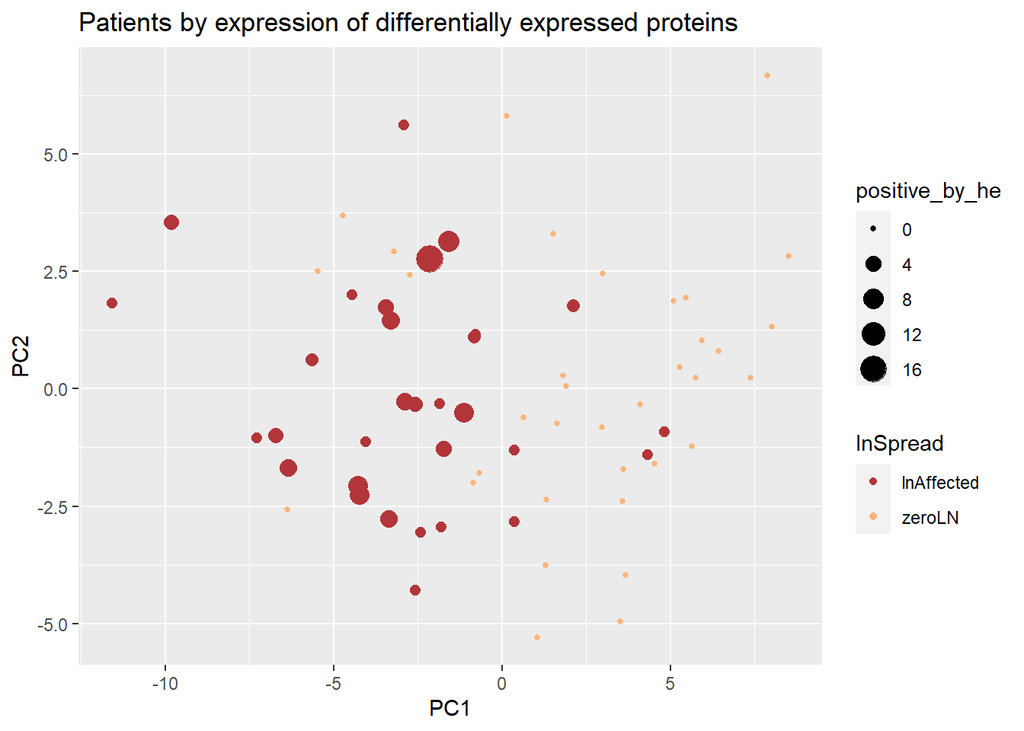

```r
##all proteins
tumAbund%>%
  left_join(select(red.dat,c(patient,lnSpread)),by='patient')%>%
ggplot()+
  geom_point(aes(x=PC1,y=PC2,col=lnSpread,size=positive_by_he))+
  ggtitle('Patients by expression of differentially expressed proteins')+
  scale_color_manual(values=pal)
```

## Normal protein expression changes

Do the normal proteins also give indication of changes in LN status?

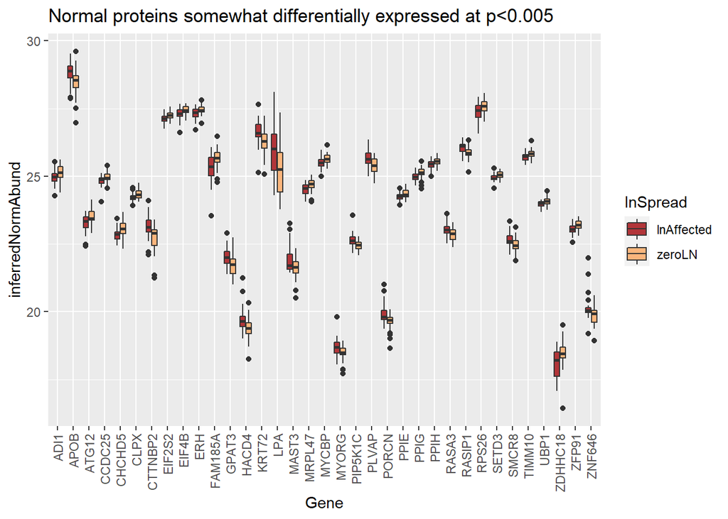

```r
#create data matrix of samples and collect patients
protMat<-normProts%>%
        pivot_wider(values_from='inferredNormAbund',names_from='patient')%>%
        tibble::column_to_rownames('Gene')

zpats=red.dat%>%subset(lnSpread=='zeroLN')%>%
        select(patient)%>%
        subset(patient%in%colnames(protMat))

opats=red.dat%>%subset(lnSpread=='lnAffected')%>%
        select(patient)%>%
        subset(patient%in%colnames(protMat))

oneVsZero=doLim(protMat,opats$patient,zpats$patient)

oneVsZero%>%subset(P.Value<0.005)%>%
  rename(Gene='featureID')%>%left_join(normProts)%>%
  left_join(red.dat)%>%
  ggplot(aes(x=Gene,y=inferredNormAbund))+geom_boxplot(aes(fill=lnSpread))+scale_x_discrete(guide = guide_axis(angle = 90))+ggtitle('Normal proteins somewhat differentially expressed at p<0.005')+scale_fill_manual(values=pal)
```

### Normal biological processes

What processes are enriched?

```r
library(leapr)

data("ncipid")
data('krbpaths')
z.en <- leapR(geneset=ncipid,enrichment_method='enrichment_in_order',datamatrix=oneVsZero,primary_columns='logFC')%>%
        subset(BH_pvalue<0.05)

DT::datatable(select(z.en,-ingroupnames))
```

|  | ingroup_n | ingroup_mean | outgroup_n | outgroup_mean | score | oddsratio | pvalue | BH_pvalue | SignedBH_pvalue | background_n | background_mean | zscore |
| --- | --- | --- | --- | --- | --- | --- | --- | --- | --- | --- | --- | --- |
| integrin1_pathway | 45 | -0.0849831439897609 | 9916 | -0.0130009254551097 |  | 0.318479673703554 | 0.000241532623193708 | 0.0468573288995793 | -0.0468573288995793 |  |  | -0.521153981746864 |

### Plot changing proteins in tumors

Now let’s see if we can plot the patient samples by the proteins involved

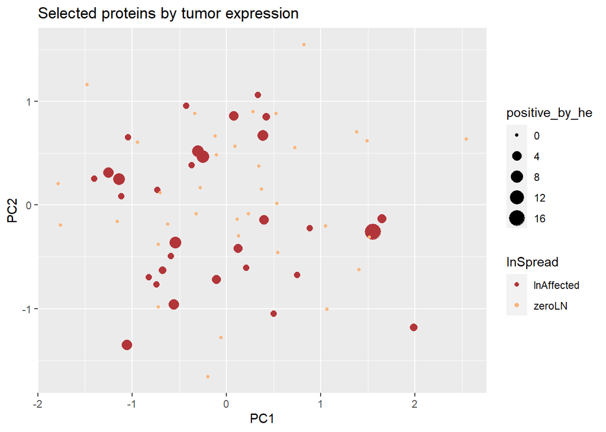

```r
zprots=subset(oneVsZero,P.Value<0.005)%>%select(featureID)

redProts <- fullProts%>%
  subset(Gene%in%zprots$featureID)

##let's first do a PCA plotted with positive lns
tumAbund <- pcaFromDf(redProts,'inferredTumAbund')%>%
  left_join(clin.dat,by='patient')

##all proteins
tumAbund%>%
  left_join(select(red.dat,c(patient,lnSpread)),by='patient')%>%
ggplot()+
  geom_point(aes(x=PC1,y=PC2,col=lnSpread,size=positive_by_he))+
  ggtitle('Selected proteins by tumor expression')+scale_color_manual(values=pal)
```

## Evaluate imaging data

first remove outliers

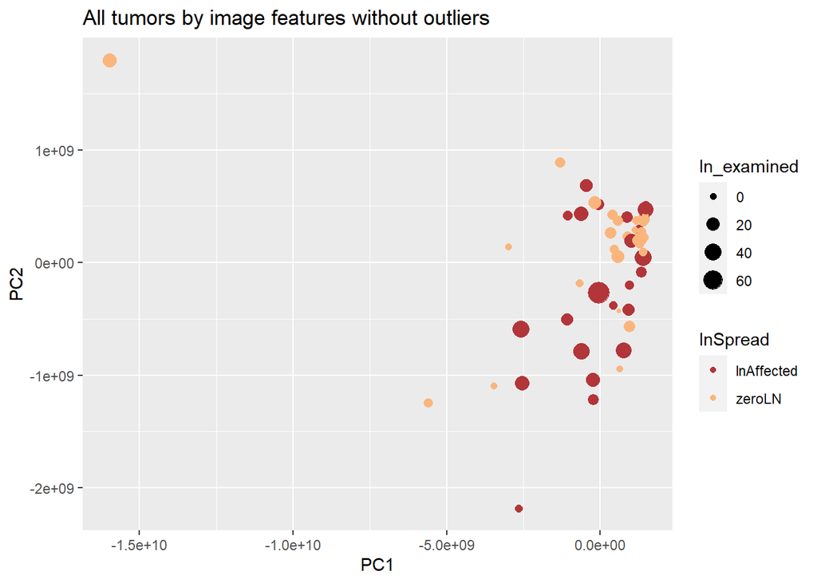

```r
imgVals <- pcaFromDf(rename(imgFeat,Gene='Feature_Type'),'value')%>%
  left_join(clin.dat,by='patient')%>%
  left_join(select(red.dat,c(patient,lnSpread)),by='patient')


outliers <- imgVals%>%subset(PC1<(-10e9)|PC2<(-2e9))%>%
  select(patient)


imgFeat <- imgFeat%>%
  subset(patient!=outliers$patient)

imgVals <- pcaFromDf(rename(imgFeat,Gene='Feature_Type'),'value')%>%
  left_join(clin.dat,by='patient')%>%
  left_join(select(red.dat,c(patient,lnSpread)),by='patient')

##all proteins
ggplot(imgVals)+
  geom_point(aes(x=PC1,y=PC2,size=ln_examined,col=lnSpread))+
  ggtitle('All tumors by image features without outliers')+scale_color_manual(values=pal)
```

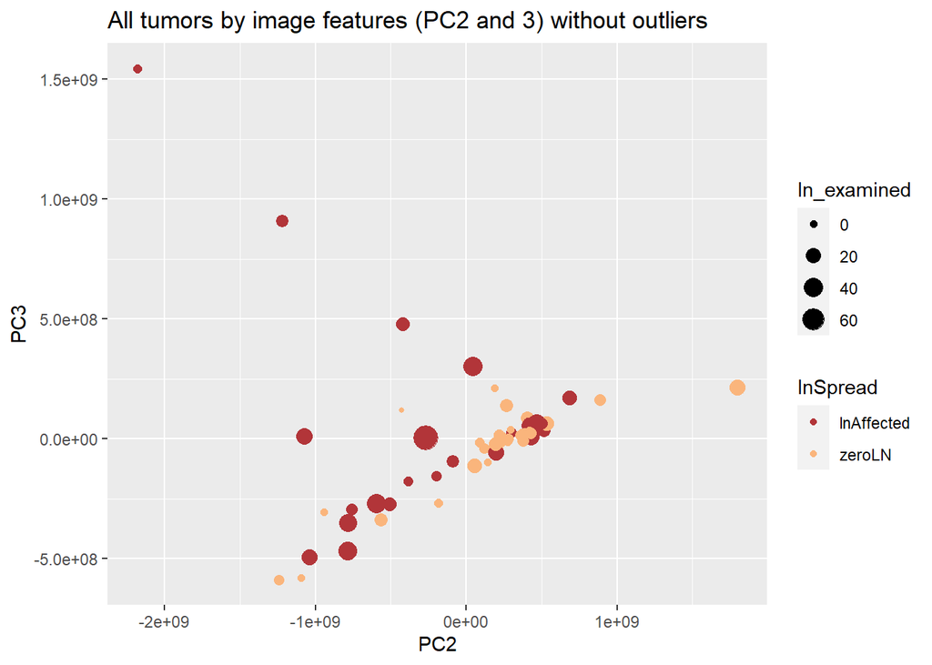

```r
##all proteins
ggplot(imgVals)+
  geom_point(aes(x=PC2,y=PC3,size=ln_examined,col=lnSpread))+
  ggtitle('All tumors by image features (PC2 and 3) without outliers')+scale_color_manual(values=pal)
```

## Select image features correlated wtih LN Spread

Here we use LIMMA to evaluate image features. None are significant but at least we can work with them.

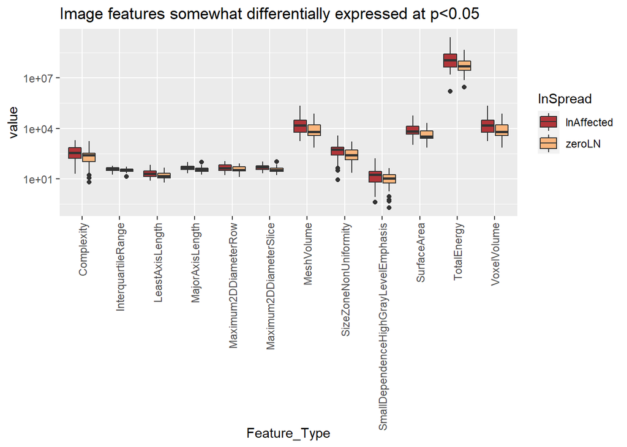

```r
library(limma)

#create data matrix of samples and collect patients
imgMat<-imgFeat%>%
  select(-Feature_Class)%>%
        pivot_wider(values_from='value',names_from='patient',values_fn=(value=mean))%>%
        tibble::column_to_rownames('Feature_Type')

zpats=red.dat%>%subset(lnSpread=='zeroLN')%>%
        select(patient)%>%
        subset(patient%in%colnames(imgMat))

opats=red.dat%>%subset(lnSpread=='lnAffected')%>%
        select(patient)%>%
        subset(patient%in%colnames(imgMat))


doLim<-function(dat,sampleIDs.group1,sampleIDs.group2){
  fac <- factor(rep(c(2,1), c(length(sampleIDs.group2), length(sampleIDs.group1))))
  design <- model.matrix(~fac)
  fit <- lmFit(dat[,c(sampleIDs.group2, sampleIDs.group1)], design)
  fit <- eBayes(fit)
  res <- topTable(fit, coef=2, number=Inf, sort.by="none")
  res <- data.frame(featureID=rownames(res), res, stringsAsFactors = F)
  return(res)
}

oneVsZero=doLim(imgMat,opats$patient,zpats$patient)
sigFeatures<-oneVsZero%>%arrange(P.Value)%>%subset(P.Value<0.05)

oneVsZero%>%subset(featureID%in%sigFeatures$featureID)%>%
  rename(Feature_Type='featureID')%>%left_join(imgFeat)%>%
  left_join(red.dat)%>%
  ggplot(aes(x=Feature_Type,y=value))+geom_boxplot(aes(fill=lnSpread))+scale_x_discrete(guide = guide_axis(angle = 90))+scale_y_log10()+ggtitle('Image features somewhat differentially expressed at p<0.05')+scale_fill_manual(values=pal)
```

```r
##now
```

These are the features of interest now - the ones that are significantly associated with LN status (before correction).

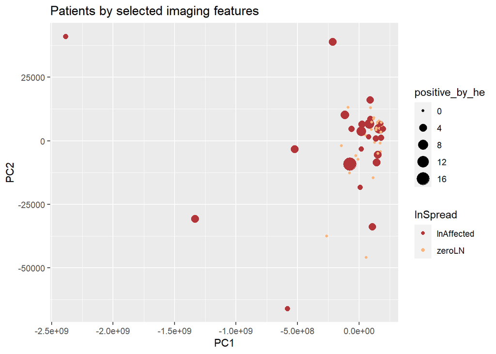

```r
zprots=subset(oneVsZero,P.Value<0.05)%>%select(featureID)

redProts <- imgFeat%>%
  subset(Feature_Type%in%c(zprots$featureID))

##let's first do a PCA plotted with positive lns
tumAbund <- pcaFromDf(rename(redProts,Gene='Feature_Type'),'value')%>%
  left_join(clin.dat,by='patient')

##all proteins
tumAbund%>%
  left_join(select(red.dat,c(patient,lnSpread)),by='patient')%>%ggplot()+
  geom_point(aes(x=PC1,y=PC2,col=lnSpread,size=positive_by_he))+
  ggtitle('Patients by selected imaging features')+scale_color_manual(values=pal)
```

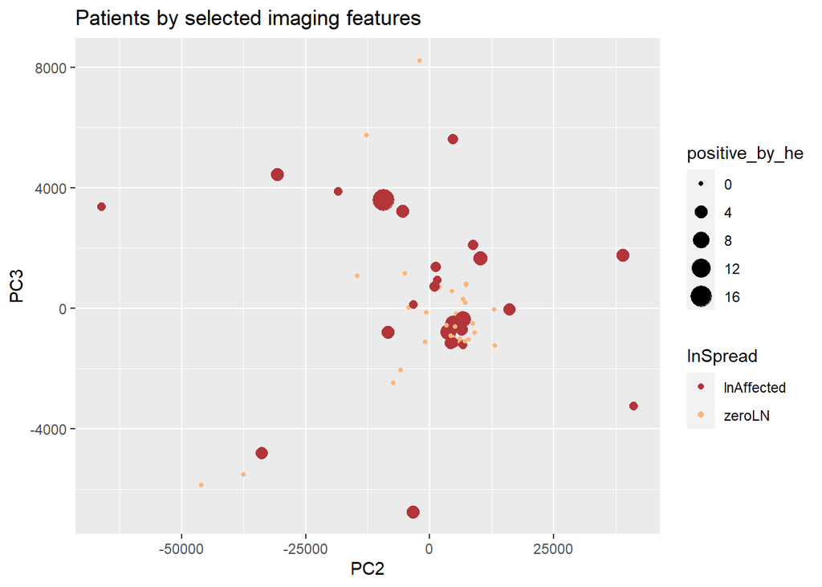

```r
tumAbund%>%left_join(select(red.dat,c(patient,lnSpread)),by='patient')%>%
ggplot()+
  geom_point(aes(x=PC2,y=PC3,col=lnSpread,size=positive_by_he))+
  ggtitle('Patients by selected imaging features')+scale_color_manual(values=pal)
```